# Week 6 - Simulation Project

STAT 420, Summer 2020, William Sayer

6/20/2020

# 1 Simulation Study 1: Significance of Regression

## 1.1 Introduction

In this simulation study I investigate the significance of regression test. I simulate using two different models:

1. The **“significant”** model

$$Y_i = \beta_0 + \beta_1 x_{i1} + \beta_2 x_{i2} + \beta_3 x_{i3} + \epsilon_i$$

where $\epsilon_i \sim N(0, \sigma^2)$ and

- $\beta_0 = 3$
- $\beta_1 = 1$
- $\beta_2 = 1$
- $\beta_3 = 1$
2. The **“non-significant”** model

$$Y_i = \beta_0 + \beta_1 x_{i1} + \beta_2 x_{i2} + \beta_3 x_{i3} + \epsilon_i$$

where $\epsilon_i \sim N(0, \sigma^2)$ and

- $\beta_0 = 3$
- $\beta_1 = 0$
- $\beta_2 = 0$
- $\beta_3 = 0$

For both, I consider a sample size of $25$ and three possible levels of noise.

- $n = 25$
- $\sigma \in (1, 5, 10)$

For each of the three values of $\sigma$, I use simulation to obtain an emperical distribution for each of the following values:

- The **$F$ statistic** for the significance of regression test
- The **p-value** for the significance of regression test
- The **$R^2$** value to represent what proportion of the total error is explained by the model

For each model and $\sigma$ combination, I use $2000$ simulations. For each simulation, I fit a regression model of the same form used to perform the simulation.

This simulation study uses the data found in `study_1.csv` for the values of the predictors. These are kept constant for the entirety of this study (the `y` values in this data are a blank placeholder).

## 1.2 Methods

Set the seed for randomization.

```r
birthday = 19930413
set.seed(birthday)
```

Initialize noise and models as described above.

```r
# number of simulations
num_sim = 2000

# initialize noise levels
sigma_vals = c(1 ,5, 10)

# initialize the two models
models = c("Significant", "Non-Significant")
beta_coef = data.frame(c(3, 1, 1, 1), c(3, 0, 0, 0))
colnames(beta_coef) = models
```

Initialize X matrix predictors from data found in `study_1.csv`.

```r
# load data from "study_1.csv"
sim1_data = read.csv("study_1.csv")

# initialize X matrix
sample_size = nrow(sim1_data)
x0 = rep(1, sample_size)
X = cbind(x0, sim1_data[["x1"]], sim1_data[["x2"]], sim1_data[["x3"]])

# covariance matrix C
C = solve(t(X) %*% X)
```

Initialize a dataframe to store the results of the simulation.

```r
# the total number of records we will need to store
num_trials = length(models) * length(sigma_vals) * num_sim

sim1_results = data.frame(model = rep("x", num_trials),
                          sigma = rep(0, num_trials),
                          f_stat = rep(0.0, num_trials),
                          p_val = rep(0.0, num_trials),
                          r_squared = rep(0.0, num_trials),
                          b0 = rep(0.0, num_trials),
                          b1 = rep(0.0, num_trials),
                          b2 = rep(0.0, num_trials),
                          b3 = rep(0.0, num_trials)
                          )
```

Simulate $2000$ times for each noise in each model.

```r
cur_trial = 1

for (model in models){
  for (sig in sigma_vals){
    for (i in seq(1, num_sim)){

      # error vector for randomization of simulated dataset
      error_vec = rnorm(sample_size, mean = 0, sd = sig)

      # calculate the simulated y-values from e known model and new error vector
      sim1_data["y"] = X %*% beta_coef[[model]] + error_vec

      # fit the model based on the model formula
      temp_mod = lm(y ~ ., data = sim1_data)

      # grab the F-Statistic, p-value, and R^2 for the model
      f_stat_val = summary(temp_mod)$fstatistic[[1]]
      p_val = 1 - pf(f_stat_val, df1 = summary(temp_mod)$fstatistic[[2]], df2 = summary(temp_mod)$fstatistic[[3]])
      r_sq = summary(temp_mod)$r.squared

      # store results of the fit model
      sim1_results[cur_trial, "model"] = model
      sim1_results[cur_trial, "sigma"] = sig
      sim1_results[cur_trial, "f_stat"] = f_stat_val
      sim1_results[cur_trial, "p_val"] = p_val
      sim1_results[cur_trial, "r_squared"] = r_sq
      sim1_results[cur_trial, "b0"] = summary(temp_mod)$coef[1, "Estimate"]
      sim1_results[cur_trial, "b1"] = summary(temp_mod)$coef[2, "Estimate"]
      sim1_results[cur_trial, "b2"] = summary(temp_mod)$coef[3, "Estimate"]
      sim1_results[cur_trial, "b3"] = summary(temp_mod)$coef[4, "Estimate"]

      cur_trial = cur_trial + 1
    }
  }
}
```

## 1.3 Results

### 1.3.1 Coefficents: Significant

Results of the fitted $\hat\beta$ coefficients for the Significant Model, displaying actual against the known *true* distribution.

#### 1.3.1.1 Sigma: 1

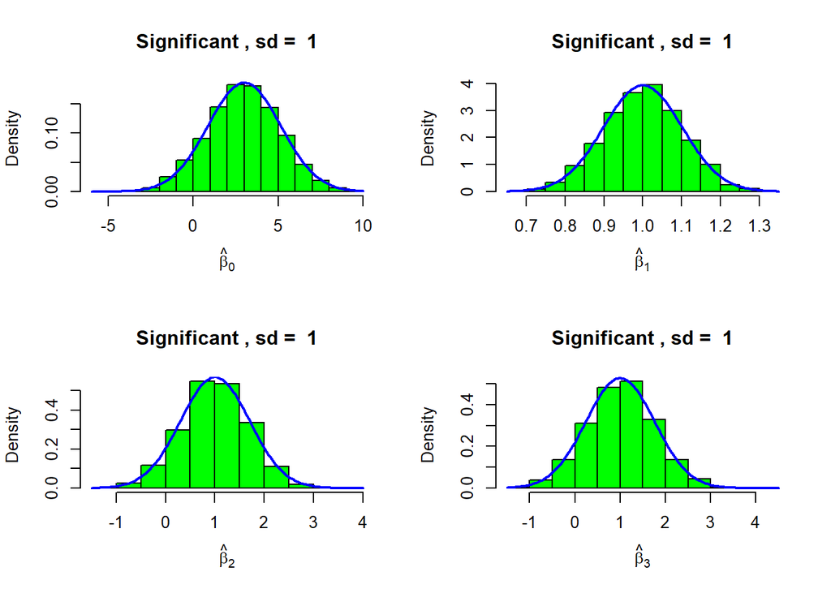

#### 1.3.1.2 Sigma: 5

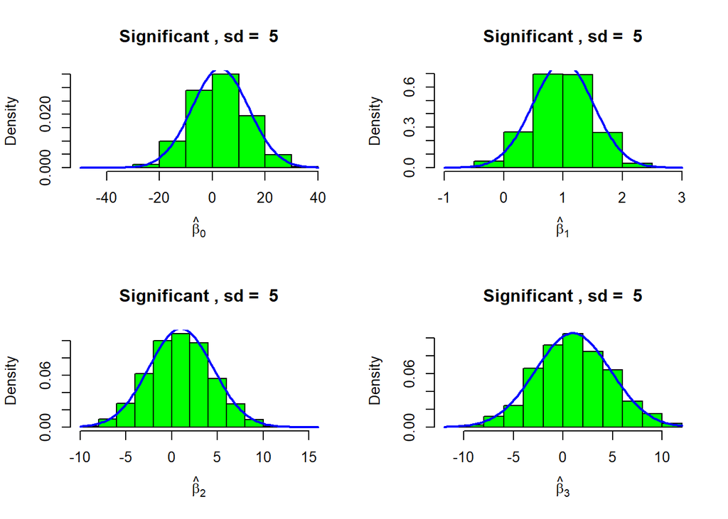

#### 1.3.1.3 Sigma: 10

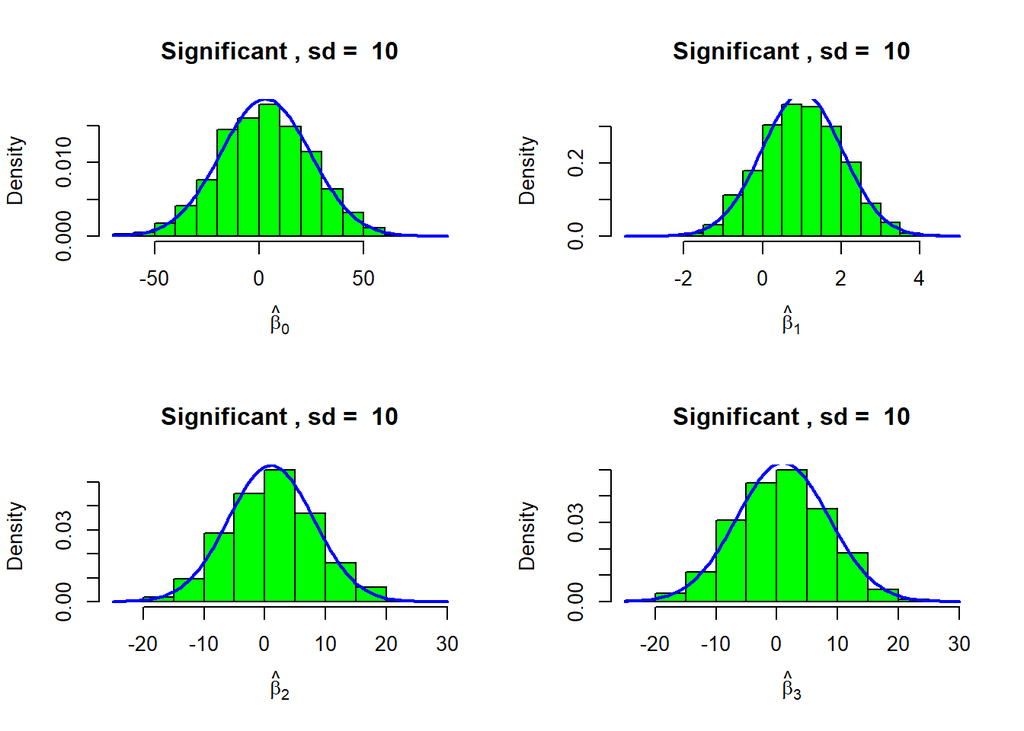

### 1.3.2 Coefficents: Non-Significant

Results of the fitted $\hat\beta$ coefficients for the Non-Significant Model, displaying actual against the known *true* distribution.

#### 1.3.2.1 Sigma: 1

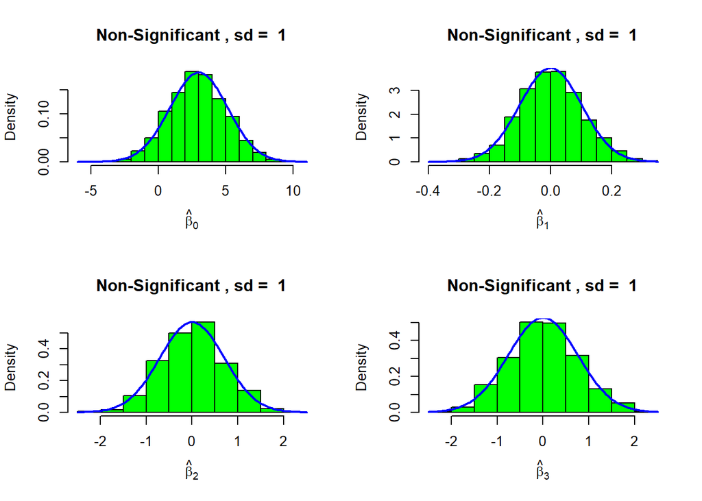

#### 1.3.2.2 Sigma: 5

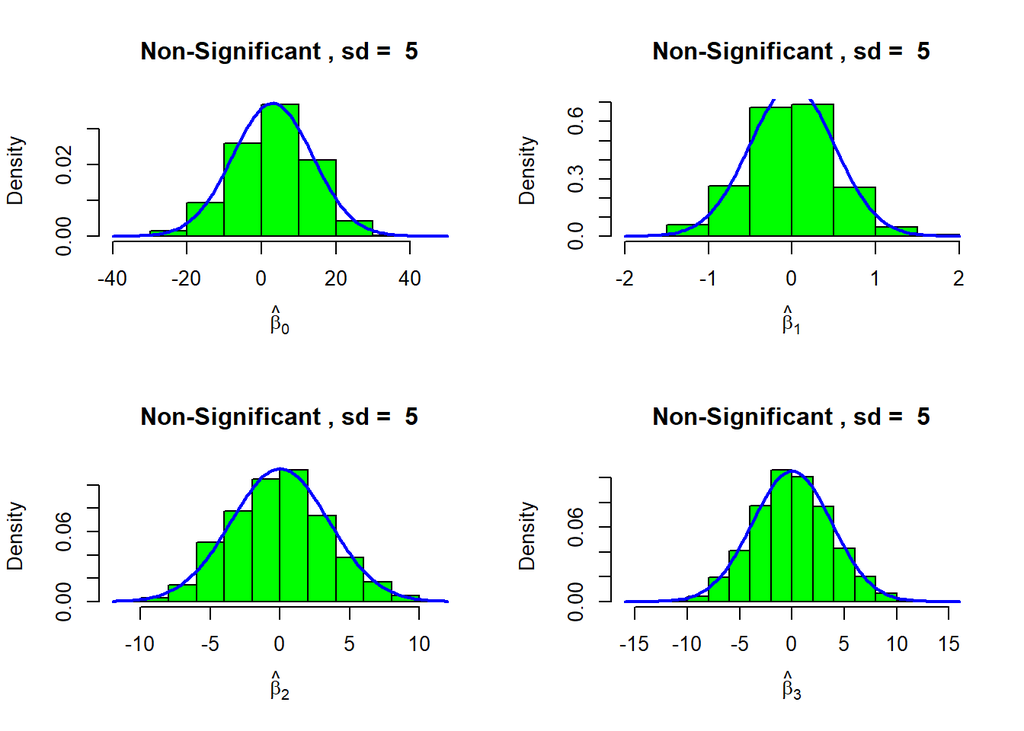

#### 1.3.2.3 Sigma: 10

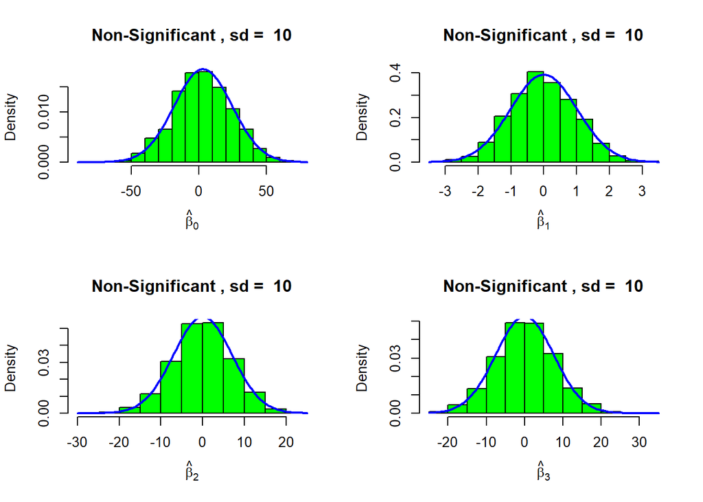

### 1.3.3 Statistics: Significant

Results of the F-Statistic, p-value, and $R^2$ values for the models fit to the Significant Model.

#### 1.3.3.1 F-Statistic

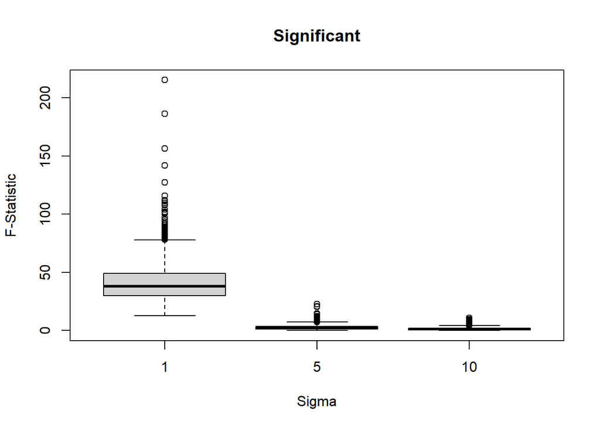

#### 1.3.3.2 p-value

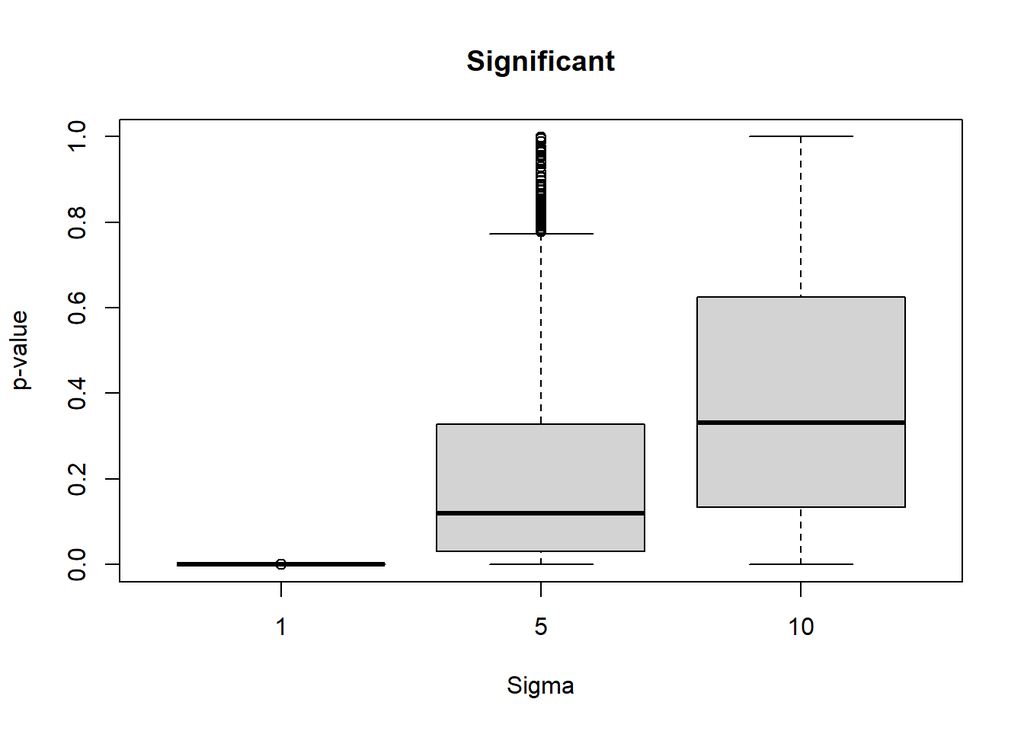

#### 1.3.3.3 $R^2$

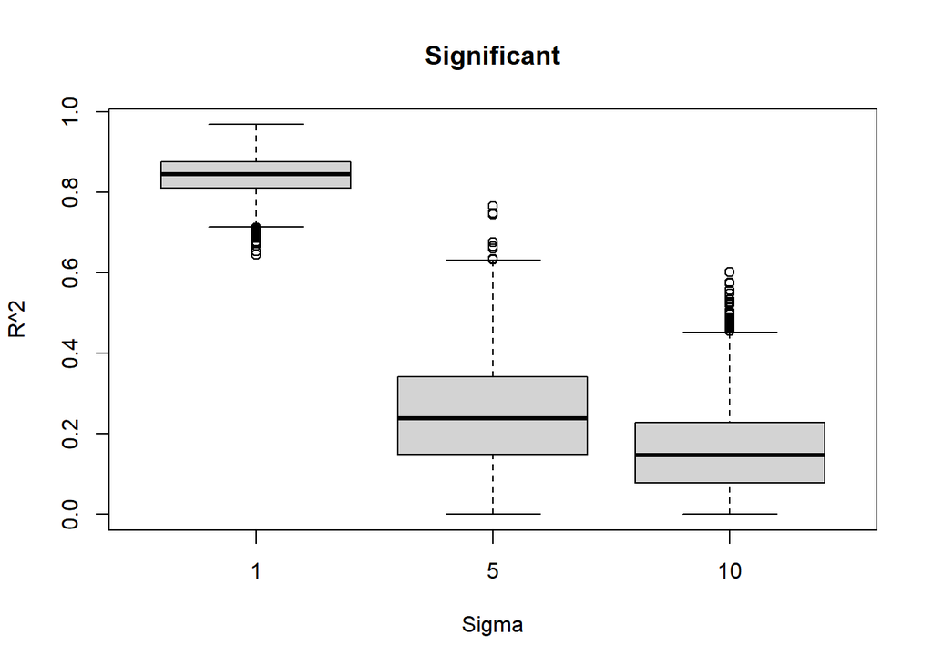

### 1.3.4 Statistics: Non-Significant

Results of the F-Statistic, p-value, and $R^2$ values for the models fit to the Non-Significant Model.

#### 1.3.4.1 F-Statistic

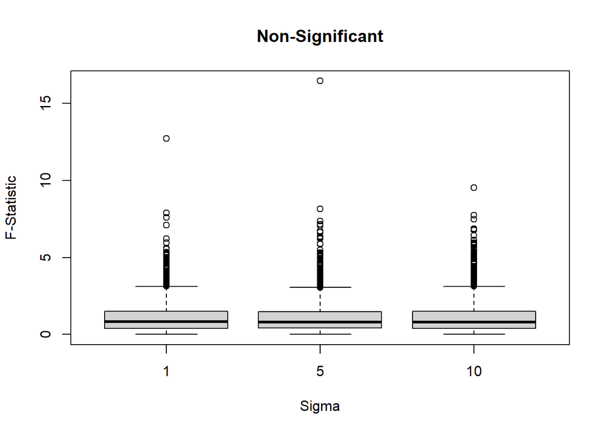

#### 1.3.4.2 p-value

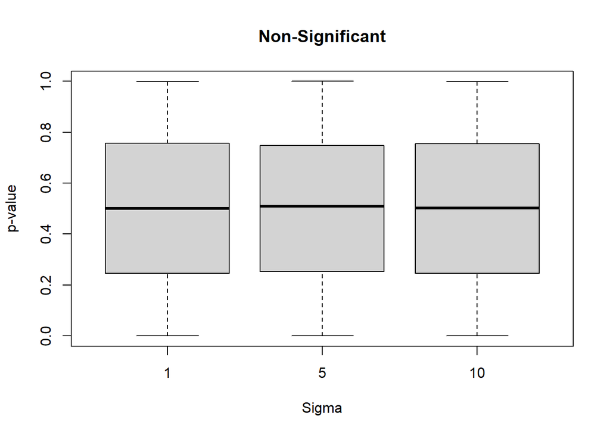

#### 1.3.4.3 $R^2$

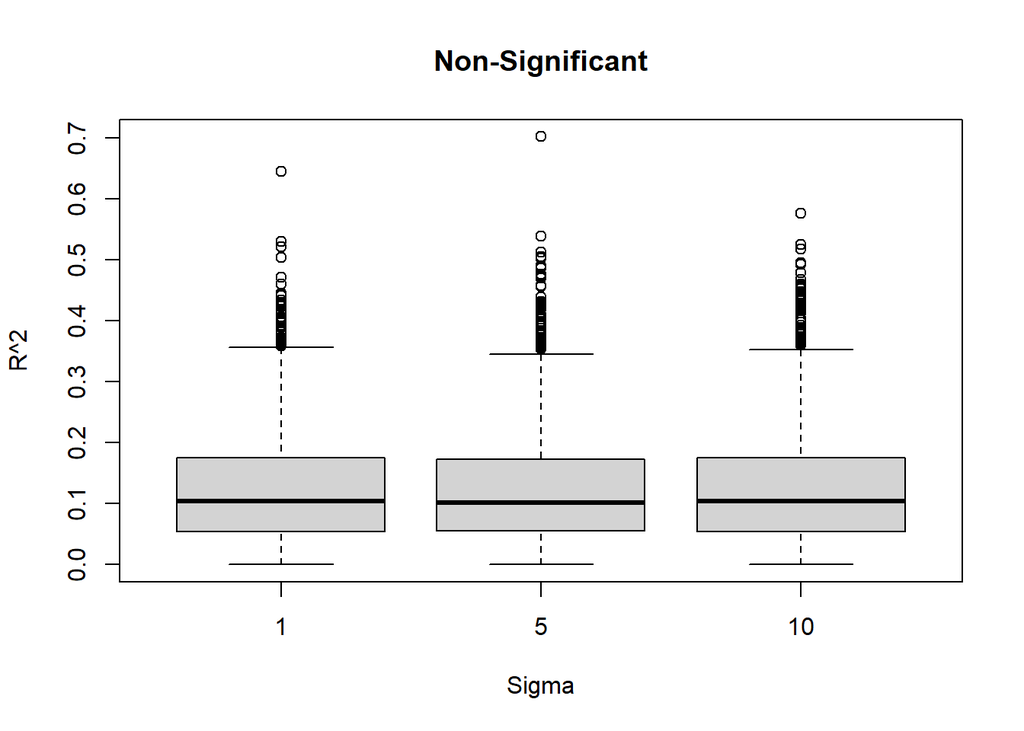

## 1.4 Discussion

### 1.4.1 Coefficients

As a way to ensure the simulations ran as expected I plotted the true distribution of $\hat\beta_j$ values against the simulated distributions. We know these because,

$$\hat\beta_j \sim N(\beta_j, \sigma^2 C_{jj})$$

where,

$$C = (X^TX)^{-1}$$

As can be seen from the *Coefficent* charts in *Results* the simulated distributions came out very similar to the true distributions for both the Significant and Non-Significant models. This is because the model does not have to be significant in order to know these distributions. As long as we know $\beta_j$ and $\sigma$, we can plot the true distribution of $\hat\beta_j$ for any given $X$.

### 1.4.2 F-Statistic: Significant

For the **Significant** model, both the mean and the variance of the F-Statistic decrease as the noise, $\sigma$ increases. This makes sense because a larger F-Statistic in the *significance of regression* test indicates greater significance.

As we introduce more noise into the simulated dataset, we increase the mean square error to the *full* model, $MSE$, while keeping the mean square difference between the *null* model and the *full* model, $MSD$, relatively constant. Since $F$ is defined as,

$$F = \frac{MSD}{MSE}$$

increasing the noise has the effect of decreasing the resulting value of $F$.

### 1.4.3 F-Statistic: Non-Significant

Looking at the **Non-Significant** model, both the mean and the variance of the resulting F-Statistics are relatively constant as $\sigma$ increases. This is because by definition, the Non-Significant model is not a significant regression of $Y$. We know this model is insignificant because the $\beta_j = 0$ for $j = 1, 2, 3$ and the resulting model is,

$$Y_i = 3 + \epsilon_i$$

In the *significance of regression* test, the null model is,

$$Y = \bar y$$

The only reason we can run a significance of regression test on the Non-Significant model is because we effectively fit the simulated data to the formula `y ~ x1 + x2 + x3`. If we had instead fit the model to the true formula `y ~ 1`, we would not be able to run a significance of regression test on the fitted model because there would be 0 degrees of freedom between the *null* and *full* models; they would be the same.

### 1.4.4 p-value

For the **Significant Model**, the p-value increases with noise. This is what we would expect to see because the p-value is the probability (area) on the tail end of the F distribution, and as I stated above, the F-Statistic decreases with noise.

For the **Non-Significant Model**, the p-value averages around and is evenly distributed around 0.5. Again this is due to the fact that the *true* model is the same as the null model. The p-value at the mean F-statistic is 0.5. The even distibution around the mean is due to the randomness produced by the simulation.

### 1.4.5 $R^2$

For the **Significant Model**, the $R^2$ value decreases as we increase noise. This is what we expect to see because with low noise, there is significance in the regression, so we expect to see a majority of the total error being explained by the regression. However as we introduce more noise, more of the error is random (by definition). As a result, the $R^2$ value decreases.

# 2 Simulation Study 2: Using RMSE for Selection

## 2.1 Introduction

In this simulation study I investigate how well Test RMSE selects the “best” model. I will simulate from the following true model:

$$Y_i = \beta_0 + \beta_1 x_{i1} + \beta_2 x_{i2} + \beta_3 x_{i3} + \beta_4 x_{i4} + \beta_5 x_{i5} + \beta_6 x_{i6} + \epsilon_i$$

where $\epsilon_i \sim N(0, \sigma^2)$ and

- $\beta_0 = 0$,
- $\beta_1 = 3$,
- $\beta_2 = -4$,
- $\beta_3 = 1.6$,
- $\beta_4 = -1.1$,
- $\beta_5 = 0.7$,
- $\beta_6 = 0.5$.

I consider a sample size of $500$ and three possible levels of noise.

- $n = 500$
- $\sigma \in (1, 2, 4)$

This simulation study uses the data found in `study_2.csv` for the values of the predictors. These are kept constant for the entirety of this study (the `y` values in this data are a blank placeholder).

Each time I simulate the data, I randomly split the data into train and test sets of equal sizes (250 observations for training, 250 observations for testing).

For each, I fit **nine** models, with forms:

- `y ~ x1`
- `y ~ x1 + x2`
- `y ~ x1 + x2 + x3`
- `y ~ x1 + x2 + x3 + x4`
- `y ~ x1 + x2 + x3 + x4 + x5`
- `y ~ x1 + x2 + x3 + x4 + x5 + x6` (the correct form of the model as noted above)
- `y ~ x1 + x2 + x3 + x4 + x5 + x6 + x7`
- `y ~ x1 + x2 + x3 + x4 + x5 + x6 + x7 + x8`
- `y ~ x1 + x2 + x3 + x4 + x5 + x6 + x7 + x8 + x9`

For each model, I calculate Train and Test RMSE.

$$\text{RMSE}(\text{model, data}) = \sqrt{\frac{1}{n} \sum_{i = 1}^{n}(y_i - \hat{y}_i)^2}$$

I repeat this process with $1000$ simulations for each of the $3$ values of $\sigma$.

## 2.2 Methods

Set the seed for randomization.

```r
set.seed(birthday)
```

Initalize model and noise levels.

```r
# number of simulations
num_sim = 1000

# initialize noise levels
sigma_vals = c(1 , 2, 4)

# initialize model
beta_coef = data.frame(standard = c(0, 3, -4, 1.6, -1.1, 0.7, 0.5))
models = names(beta_coef)
```

Initialize X matrix predictors from data found in `study_2.csv`.

```r
# load data from "study_2.csv"
sim_data = read.csv("study_2.csv")
x0 = rep(1, nrow(sim_data))
X = as.matrix(cbind(x0, sim_data[2: 7]))

# define the split between the test and training sets
train_split = 0.5
train_size = round(nrow(sim_data) * train_split, 0)
#test_size = nrow(sim_data) - train_size

# number of parameters which also happens to be the number of formulas to test
num_params = ncol(sim_data) - 1
```

Dynamically write the formulas to be tested.

```r
# initalize a vector to store the formulas to test
test_forms = rep(c(as.formula(paste("y ~ x"))), num_params)

# number of formulas to test (which also happens to be the same as the number of parameters)
num_forms = length(test_forms)

# this for loop creates the formulas dynamically
var_names = names(sim_data)
for(i in seq(1, num_forms)){
  temp_form = as.formula(paste(var_names[1],
                               paste(var_names[2: (1+i)], collapse = " + "),
                               sep = " ~ "))
  test_forms[[i]] = temp_form
}

test_forms
```

```
## [[1]]
## y ~ x1
##
## [[2]]
## y ~ x1 + x2
##
## [[3]]
## y ~ x1 + x2 + x3
##
## [[4]]
## y ~ x1 + x2 + x3 + x4
##
## [[5]]
## y ~ x1 + x2 + x3 + x4 + x5
##
## [[6]]
## y ~ x1 + x2 + x3 + x4 + x5 + x6
##
## [[7]]
## y ~ x1 + x2 + x3 + x4 + x5 + x6 + x7
##
## [[8]]
## y ~ x1 + x2 + x3 + x4 + x5 + x6 + x7 + x8
##
## [[9]]
## y ~ x1 + x2 + x3 + x4 + x5 + x6 + x7 + x8 + x9
```

Intialize dataframe to store simulation results.

```r
# number of records needed to be stored
num_trials = num_forms * length(sigma_vals) * num_sim

# initialize dataframe to store simulation results
sim2_results = data.frame(form_i = rep(0, num_trials),
                          sigma = rep(0, num_trials),
                          train_RMSE = rep(0.0, num_trials),
                          test_RMSE = rep(0.0, num_trials),
                          sim = rep(0, num_trials)
                          )
```

Run simulation for $1000$ simulations on all formulas at each noise level.

```r
# this is the y_mean calculated from the true model
model_name = models[1]
y_mean = X %*% beta_coef[[model_name]]

# initialize dataframe to store the formula with smallest Test RMSE for each simulation
top_models = data.frame(
                        form_i = rep(0, num_sim*length(sigma_vals)),
                        sigma = rep(0.0, num_sim*length(sigma_vals))
                        )
sim_i = 1
cur_trial = 1

# loop through each noise level
for (sig in sigma_vals){

  # loop through "num_sim" simulations
  for (i in seq(1, num_sim)){

    # produce random error to simulate "y" for each simulation iteration
    error_vec = rnorm(length(sim_data), mean = 0, sd = sig)

    # calculate "y" from y_mean and error
    sim_data["y"] = y_mean + error_vec

    # split data into test and training sets
    train_idx = sample(1:nrow(sim_data), train_size)
    test_idx = setdiff(seq(1, nrow(sim_data)), train_idx)
    train_set = sim_data[train_idx, ]
    test_set = sim_data[test_idx, ]

    # initialize vector to store Test RMSE results for each formula of this simulation
    # will use to compare formulas to find the best model for the current simulation dataset
    model_comp = rep(0, num_forms)

    for (form_i in seq(1, num_forms)){

      # fit model to current formula
      test_form = test_forms[[form_i]]
      temp_mod = lm(test_form, data = train_set)

      # calculate predicted Test/Train y-values in order to calculate Test/Train RMSE
      y_pred_train = predict(temp_mod)
      y_pred_test = predict(temp_mod, newdata = test_set[2: (1 + form_i)])

      train_RMSE = sqrt(mean((train_set$y - y_pred_train)^2))
      test_RMSE = sqrt(mean((test_set$y - y_pred_test)^2))

      # store results of the simulation
      sim2_results[cur_trial, "form_i"] = form_i
      sim2_results[cur_trial, "sigma"] = sig
      sim2_results[cur_trial, "train_RMSE"] = train_RMSE
      sim2_results[cur_trial, "test_RMSE"] = test_RMSE
      sim2_results[cur_trial, "sim"] = sim_i

      # store Test RMSE for comparison of all models of this simulation instance
      model_comp[form_i] = test_RMSE

      cur_trial = cur_trial + 1
    }

    # find and store model with the lowest RMSE in this simulation
    top_models[sim_i, "form_i"] = which.min(model_comp)
    top_models[sim_i, "sigma"] = sig

    sim_i = sim_i + 1
  }
}
```

## 2.3 Results

### 2.3.1 RMSE Variation

Boxplots showing the variation of Test and Train RMSE over all the simulations for each model.

#### 2.3.1.1 Sigma: 1

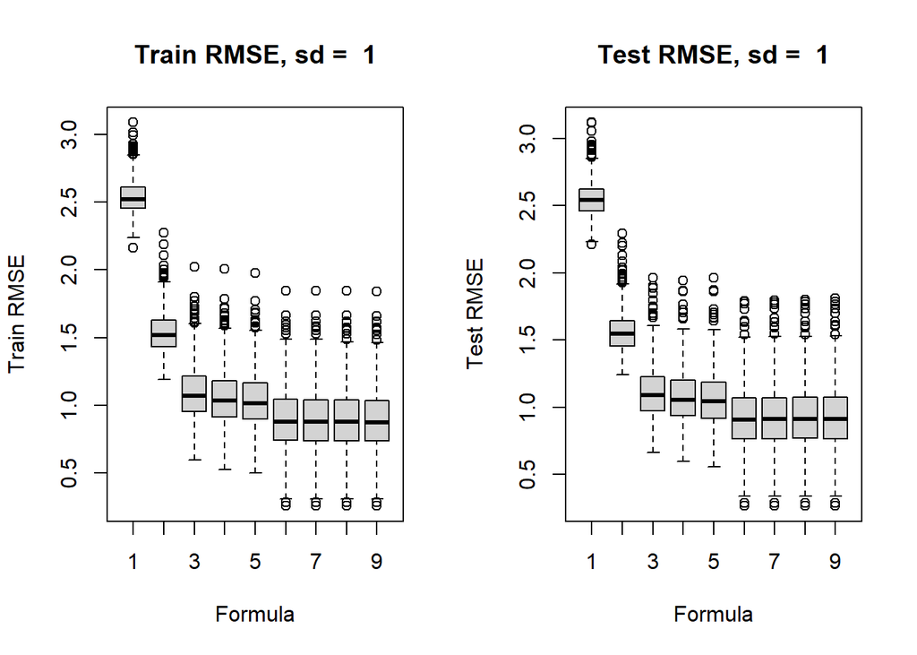

#### 2.3.1.2 Sigma: 2

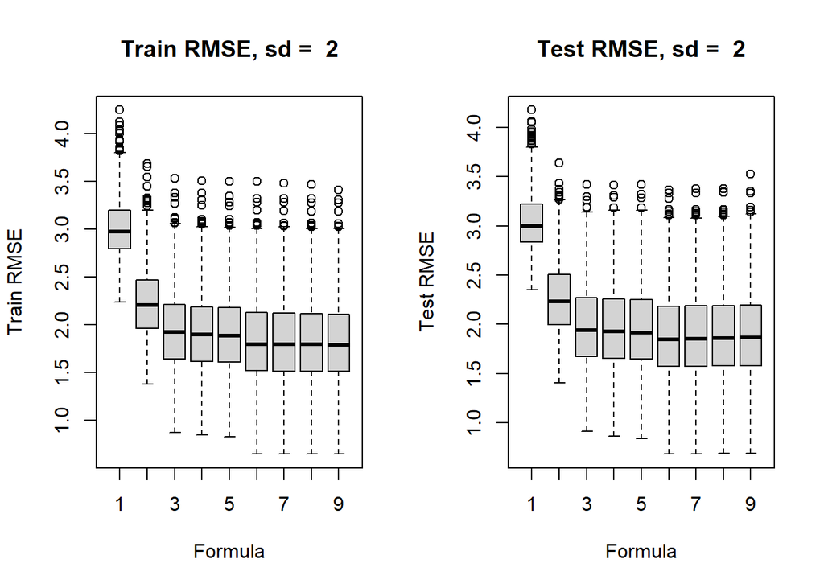

#### 2.3.1.3 Sigma: 4

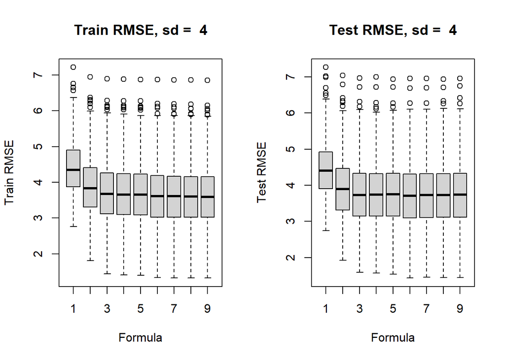

### 2.3.2 Best Model

Barplots showing the number of times a model resulted in the lowest Test RMSE over the 1000 simulations.

#### 2.3.2.1 Sigma: 1

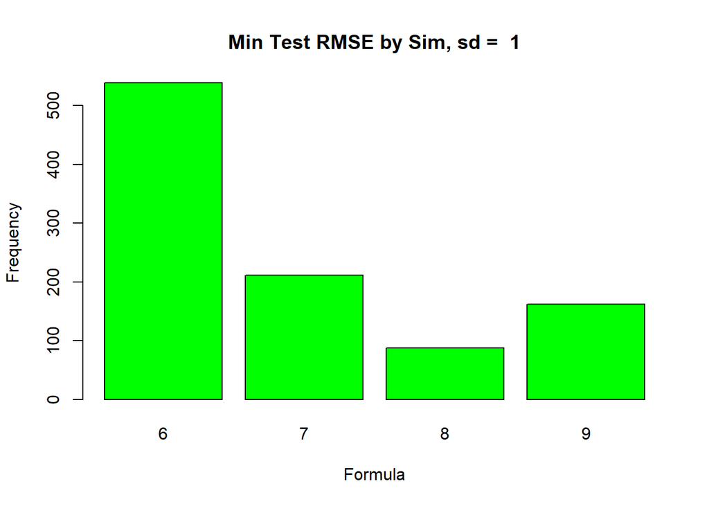

#### 2.3.2.2 Sigma: 2

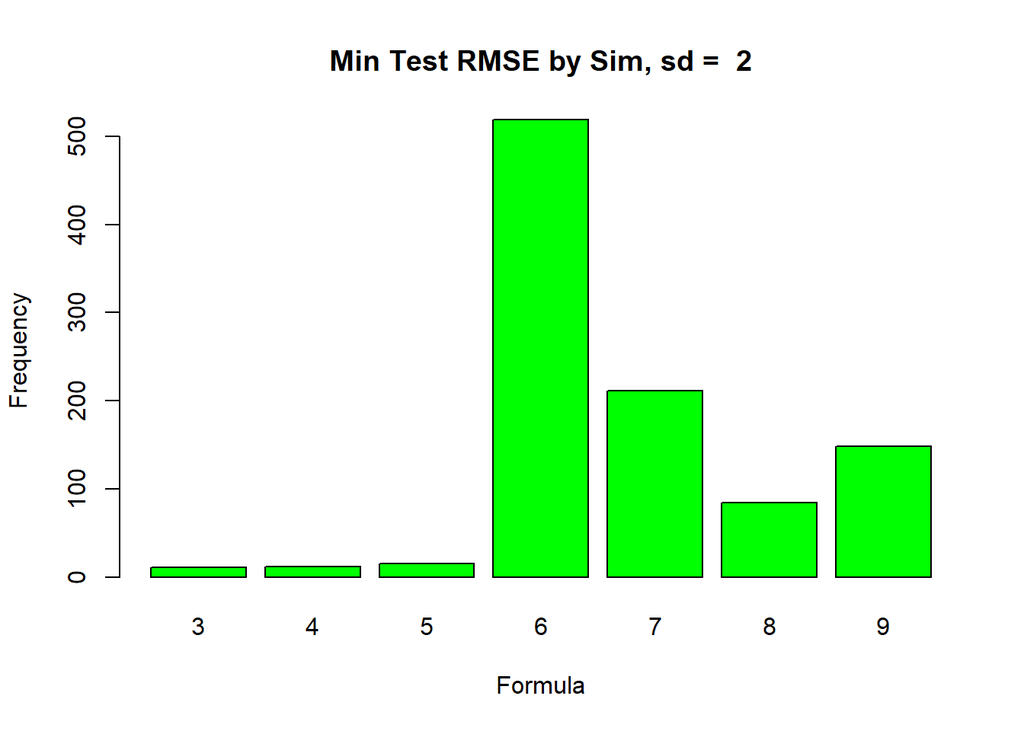

#### 2.3.2.3 Sigma: 4

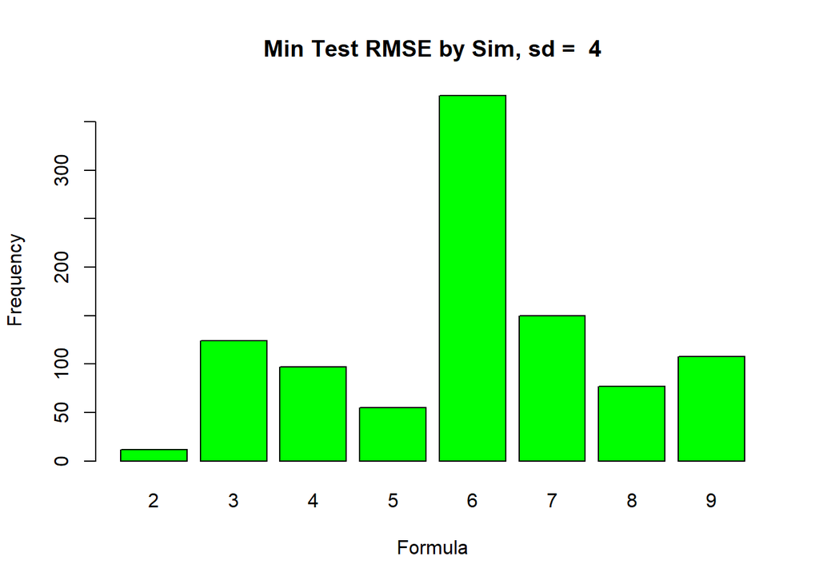

## 2.4 Discussion

### 2.4.1 RMSE Variation: Sigma

The boxplots above show the Test and Train RMSE for each of the formulas. When sigma is low, it is clear the Test and Train RMSE is significantly greater on the underfit models (1-5). As sigma increases, the difference in both Test and Train RMSE between all the models decreases.

This is what we would expect to see because as we introduce more and more noise, the significance of the regression decreases (because the standard squared error increasingly over-powers the prediction from the coefficients) and we expect all models to produce relatively similar results.

### 2.4.2 RMSE Variation: Test vs Train

Models 6-9 are all relatively similar for Test and Train RMSE on all simga levels, but their relationship changes between the Train RMSE and the Test RMSE. For the Train RMSE, the error continuously *decreases* from model 6 to 7 to 8 to 9, while the Test RMSE continuously *increases* from model 6 to 7 to 8 to 9.

We see this because when we introduce more predictors to any model the total error will either decrease or stay the same. The error will never get worse because if the predictor is so bad at predicting that it *never* helps reduce error then the regression will fit its corresponding $\beta$ coefficient to 0. If fit to zero, the predictor will have no effect on error, and if fit to a non-zero value then the predictor, by definition of the *best* regression, has helped reduce error.

However this leads to *overfitting* which is why we Test RMSE increase. Since we know the true model only has 6 predictors, any other predictors added to the model past the true 6 are unnecessary. As a result, we effectively train the model to pay attention to a variable that doesn’t help predict during training. This may help for the training set and it will reduce error for the reason stated above, but then when we measure error against the Test dataset it is now larger because the relationship fitted to the unnecessary predictor in the training set is no longer relavant (on average) in the test dataset, resulting in larger error.

As sigma increases the overfitting becomes more pronounced.

### 2.4.3 Best Model

For each simulation I selected the model that resulted in the lowest test RMSE as the best model for that simulation. The results are seen in the barplots above. For all $\sigma$ values, the true model (Model 6) is selected most often; however, the probability of it being selected decreases as $\sigma$ increases.

With $\sigma = 1$ the true model is selected ~55% of the time, while when $\sigma = 4$ the true model is selected just under 40% of the time.

The range of which models get selected also increases with sigma. When $\sigma = 1$ only models 6-9 were slected throughout the 1000 simulations. This increased to models 3-9 when $\sigma = 2$ and models 2-9 when $\sigma = 4$.

What’s interesting to point out is that the models do not necessarily get chosen more often just because they more closely resemble the true model. For example, in the noise levels tested, Model 6 is always chosen the most, Model 7 is always chosen the 2nd most, and Model 9 always gets chosen more often than Model 8. Therefore, it seems introducing and **8th** predictor to the model may result in some degree of overfitting that introducing a **9th** predictor might balance out.

Similarly, when $\sigma = 4$ Model 3 is chosen more often than models 4, 5, and 9 despite being chosen less often than all three of the models for the two lower noise levels. The same relationship is seen the Test RMSE boxplots for the mentioned models. Therefore, it’s possible Model 3 might be the 2nd best predictor at high variance, as overfitting becomes more of an issue for the other models (other than model 6).

# 3 Simulation Study 3: Power

## 3.1 Introduction

In this simulation study I investigate the **power** of the significance of regression test for simple linear regression.

$$H_0: \beta_{1} = 0 \ \text{vs} \ H_1: \beta_{1} \neq 0$$

To recall a few concepts, the *significance* level, $\alpha$, is the probability of a Type I error.

$$\alpha = P[\text{Reject } H_0 \mid H_0 \text{ True}] = P[\text{Type I Error}]$$

The probability of a Type II error is denoted using $\beta$ (not be confused with a regression parameter).

$$\beta = P[\text{Fail to Reject } H_0 \mid H_1 \text{ True}] = P[\text{Type II Error}]$$

*Power* is the probability of rejecting $H_0$ when it is not true, that is, $H_1$ is true and $\beta_{1}$ is non-zero.

$$\text{Power} = 1 - \beta = P[\text{Reject } H_0 \mid H_1 \text{ True}]$$

Therefore, power is the probability that a signal of a particular strength will be detected. Many things affect the power of a test. The parameters I investigate in this study are:

- Sample Size, $n$
- Signal Strength, $\beta_1$
- Noise Level, $\sigma$

I simulate from the following model:

$$Y_i = \beta_0 + \beta_1 x_i + \epsilon_i$$

where $\epsilon_i \sim N(0, \sigma^2)$.

For simplicity, I will let $\beta_0 = 0$, thus $\beta_1$ is essentially controlling the amount of “signal.” I will then consider different signals, noises, and sample sizes:

- $\beta_1 \in (-2, -1.9, -1.8, \ldots, -0.1, 0, 0.1, 0.2, 0.3, \ldots, 1.9, 2)$
- $\sigma \in (1, 2, 4)$
- $n \in (10, 20, 30)$

I will hold the significance level constant at $\alpha = 0.05$ *(Note: $\alpha$ also has an effect on power, but it will not be investigated in this study)*.

For each possible $\beta_1$ and $\sigma$ combination, I will simulate from the true model $1000$ and $5000$ times as a way to investigate the effect of *number of simulations* on the results. For each simulation, I will perform the significance of the regression test. Power is estimated at the given $\alpha$ with:

$$\hat{\text{Power}} = \hat{P}[\text{Reject } H_0 \mid H_1 \text{ True}] = \frac{\text{# Tests Rejected}}{\text{# Simulations}}$$

It is *possible* to derive an expression for power mathematically, but often this is difficult, so instead, I rely on simulation.

## 3.2 Methods

Set seed for randomization and initialize study parameters as detailed above.

```r
set.seed(birthday)

# initialize number of simulations and sample sizes
num_sim3 = 1000
num_sim3_2 = 5000
sample_sizes = c(10, 20, 30)

# initialize noise levels
sigma_vals3 = c(1, 2, 4)

# initialize beta values to test on
beta1_vals = seq(-2, 2, by = 0.1)

# declare significance level
alpha = 0.05
```

Initialize dataframe to store results.

```r
# total number of records we will need to store
num_records = length(sigma_vals3)*length(sample_sizes)*length(beta1_vals)

# dataframe to store results for 1000 trials and 5000 trials
sim3_results = data.frame(n = rep(0,num_records),
                          beta1 = rep(0,num_records),
                          sig = rep(0,num_records),
                          power_1000 = rep(0,num_records),
                          power_5000 = rep(0,num_records))
```

Run simulation for 5000 simulations on each $\hat\beta$ and $\sigma$ combination at each sample size. Use the first 1000 simulations to compare the effect of number of simulations on the results.

```r
curr_i = 1

# loop through all noise levels
for (sig in sigma_vals3){

  # loop through each beta value
  for (beta1 in beta1_vals){

    # loop through each sample size
    for (n in sample_sizes){

      # intialize x-vector to be used for all simulations of this sample size
      x_values = seq(0, 5, length = n)

      # initilalize vector to store the p-value of each simulation
      temp_p_vals = rep(0, num_sim3_2)

      # loop for 1000 simulations
      for (i in seq(1, num_sim3_2)){

        # initialize random error for this simulation
        ep_i = rnorm(n, mean = 0, sd = sig)

        # calculate y-values and fit the model
        y_vals = x_values*beta1 + ep_i
        temp_mod = lm(y_vals ~ x_values)

        # store p-value of the simulation
        temp_p_vals[[i]] = summary(temp_mod)$coef["x_values", "Pr(>|t|)"]
      }

      # calculate power for the current sigma, beta1, sample size combination (1000 simulations)
      power_1000 = sum(temp_p_vals[1:num_sim3] < alpha)/num_sim3
      # calculate power for the current sigma, beta1, sample size combination (5000 simulations)
      power_5000 = sum(temp_p_vals < alpha)/num_sim3_2

      # store results in a dataframe
      sim3_results[curr_i,] = data.frame(n = n,
                                         beta1 = beta1,
                                         sig = sig,
                                         power_1000 = power_1000,
                                         power_5000 = power_5000)

      curr_i = curr_i + 1
    }
  }
}
```

## 3.3 Results

### 3.3.1 Power Curves: 1000 Simulations

#### 3.3.1.1 Sigma: 1

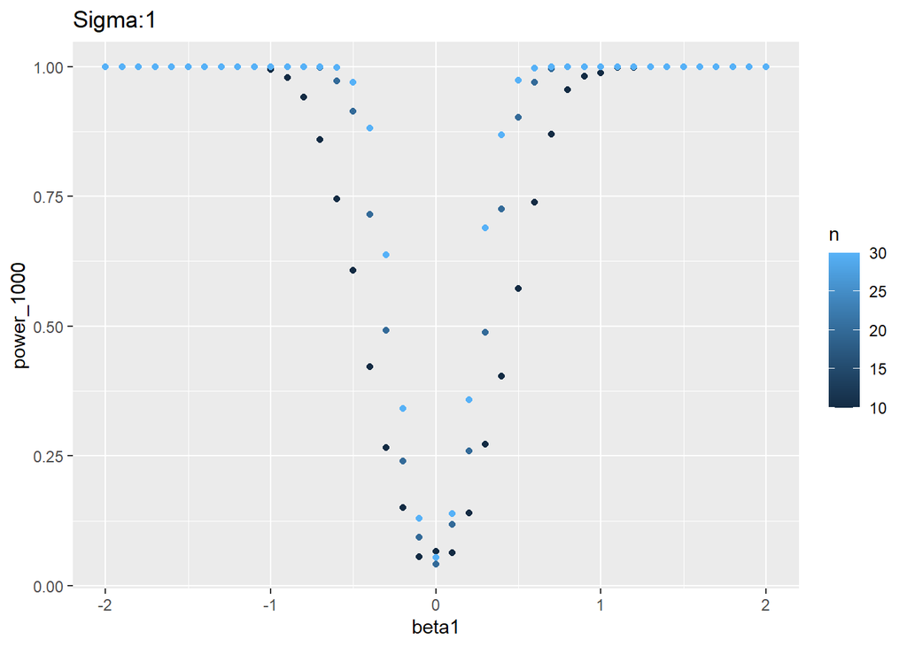

#### 3.3.1.2 Sigma: 2

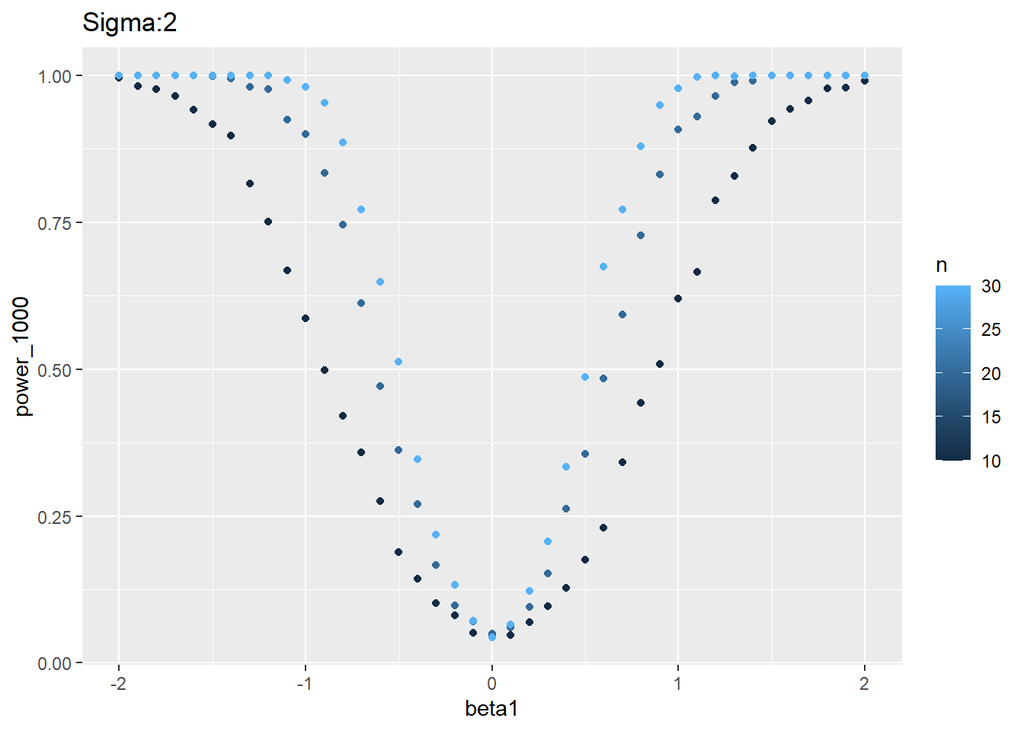

#### 3.3.1.3 Sigma: 4

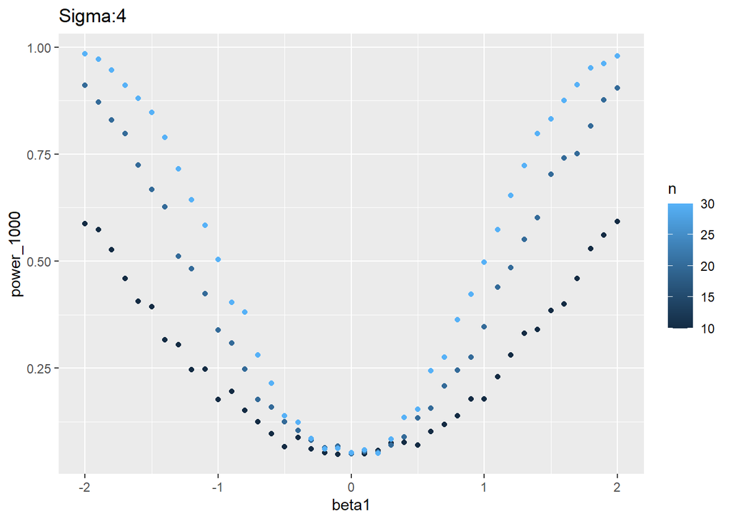

### 3.3.2 Power Curves: 5000 Simulations

#### 3.3.2.1 Sigma: 1

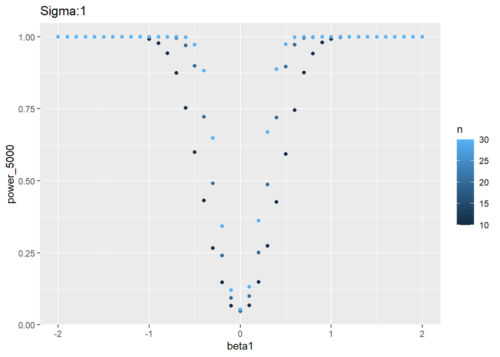

#### 3.3.2.2 Sigma: 2

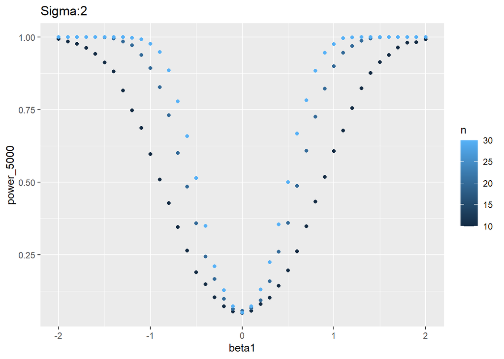

#### 3.3.2.3 Sigma: 4

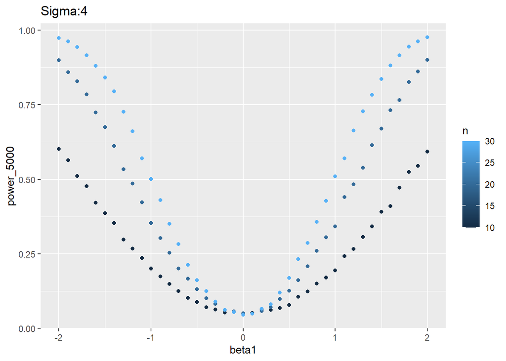

## 3.4 Discussion

### 3.4.1 Power Curves vs $\beta_1$

The Power Curves show the following relationships between $\beta_1$ and power:

1. As $\beta_1$ moves further from $H_0$ the power increases. This makes sense because as $\beta_1$ moves further away from $H_0$ ($\beta_1 = 0$) it becomes more likely we will Reject $H_0$.
2. When $\beta_1 = 0$, the power is approximately $\alpha$. This is what we would expect to see because in the the case $\beta_1 = 0$, $H_0$ is now true, meaning our method is now calculating:
   $$P[\text{Reject } H_0 \mid H_0 \text{ True}] = P[\text{Type I Error}] = \alpha$$

### 3.4.2 Sample Size

As the sample size, $n$, increases for a given $\sigma$, the power curve effectively gets skinnier. Effectively, it increases the rate at which power increases as $\beta_1$ moves further from zero. This is because the hypothesis testing is performed with a t-distribution. Therefore as we increase $n$, we are increasing the degrees of freedom the hypothesis is being tested on.

When you increase the degrees of freedom on a t-distribution, you remove area (probability) from the tails of the curve, making the curve become more *normal*. This decreases the value of the *critical value*, $t$, at which we Reject $H_0$, increasing the probability that *we will* Reject $H_0$ at a given $\beta_1$, which increases the power at that $\beta_1$.

### 3.4.3 Noise

we are increasing the critical value of the test for a given $\beta_1$.

Another way to consider the affect of $\sigma$ on power is to remember that,

$$\hat\beta_1 \sim N(\beta_1, SD[\hat\beta_1])$$

where,

$$SD[\hat\beta_1] = \frac{\sigma}{\sqrt{S_{xx}}}$$

Therefore, we are increasing the standard deviation of $\hat\beta_1$. This streches out the normal distribution of $\hat\beta_1$, making it more likely $\hat\beta_1$ will exist within the range that we Fail to Reject $H_0$. As a result, power decreases for a given $\beta_1$, which we see from our power curve results.

### 3.4.4 Simulations

The last parameter investigated in this study was the number of simulations and the affect it has on the power curves. In effect, increasing the number of simulations decreases the *noise* we see in the resulting power curves.

Using $1000$ simulations, we get a good enough idea to recognize the affect each paramater has on the curve, however the curves aren’t as smooth as they could be. This most pronounced when $n$ is small and $\sigma$ is large.

When we increase to $5000$ simulations, the curves appear significantly smoother. As stated in the introduction, these curves are not the *true* power curves, they are simply the curves produced by the simulation. This means that each power value for a given $\beta_1$ is an estimate of the true power of the hypothesis test at that $\beta_1$, and as we increase the number of simulations, the estimate will get closer and closer the to the true power.

So if you were using these power curves for an analysis where the accuracy of the curves needed to be closer to the true power, you would probably want to use something closer to 10,000 simulations, depending on your $n$ and $\sigma$.